# Bachelor në Inxhinieri Matematike dhe Informatike -2

Projekt në R:

Studenti: Fatjon Omeri Pedagogu:Lule Basha

2022-06-17

## Projekti final

### Hyrje

Ky projekt ka si qellim analizimin e nje databaze me 100 hyrje mbi llojet e ndryshme te duhanit qe prodhohet dhe importohet ne US duke perdorur softwaret R dhe RStudio.

Librarite qe jane perodur ne kete studim

```r
#*User libraries**
#library(xlsx)
#library(dplyr)
#library(ggplot2)
#library(hrbrthemes)
#library(stringr)
#library(tibble)
#library(knitr)

#*system libraries*
#library(utils)
#library(stats)
#library(methods)
#library(grDevices)
#library(base)
#library(graphics)
```

### Perpunimi i te dhenave

Importimi i te dhenave ne R

```r
library(readxl)
df <- read_excel("C:\\Users\\Hp\\Documents\\Te_dhena_per_projekt.xlsx", sheet = "Projekt 24")
```

Ndryshojme emrat e kolonave qe kane hapesire ne mes te fjaleve per te mos patur errore gjate perpunimit te te dhenave dhe ndertimit te grafikeve

```r
library(stringr)
names(df) <-str_replace_all(names(df),c(" "= "_"))
```

Meqenese duhani i djegshem (combustible) mund te matet ne ‘pounds’ dhe ne numer cigaresh ne varesi te nenllojit, do te ishte mire ti kthenim te gjitha te dhenat ne pounds, ne menyre qe te mund ti krahasojme me duhanin e padjegshem (noncombustible). Sipas te dhenave ne web marim mesataren e permbajtjes se duhanit te llojeve te ndryshme si cigare apo puro, e cila eshte 0.004 pounds per cigare.

```r
library(dplyr)
df <- df%>%mutate(Totali_Pounds = if_else(Data_Value_Unit=='Pounds', as.numeric(Total),as.numeric(Total)*0.004))
df <- df%>%mutate(Domestic_Pounds = if_else(Data_Value_Unit=='Pounds', as.numeric(Domestic),as.numeric(Domestic)*0.004))
df <- df%>%mutate(Imports_Pounds = if_else(Data_Value_Unit=='Pounds', as.numeric(Imports),as.numeric(Imports)*0.004))
```

Shohim qe ne te dhenat e tabeles kemi edhe nje qelize “All combustibles” qe permbledh te gjitha te dhenat e duhanit te djegshem ne vit dhe i liston si ekuivalente cigaresh. Kete rresht mund ta heqim nga tabela pasi llogarite do ti bejme ne pound.

```r
df <- df[!grepl('All Combustibles',df$Measure),]
```

### Analiza e te dhenave 1

**Ne kete tab do te analizojme lidhjen midis duhanit te djegshem dhe te padjegshem si dhe ndryshimin e tyre pergjate viteve.**

Si fillim nxjerrim shumen ne pound te secilit lloj ne total pergjat te gjithe viteve:

```r
comb = sum(df[which(df$Topic=='Combustible Tobacco'), 15])
noncomb = sum(df[which(df$Topic=='Noncombustible Tobacco'), 15])
```

Me keto te dhena mund te ndertojme nje grafik rrethor dhe me shtylla per ta patur te qarte nga ana vizuale raportin e tyre.

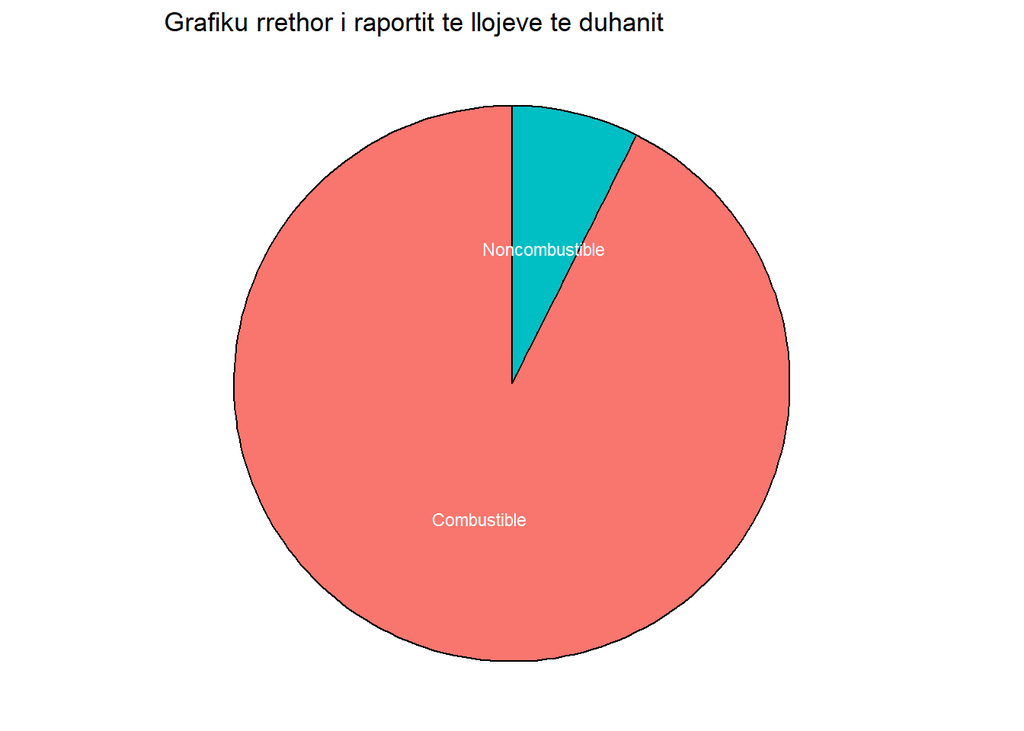

```r
library(ggplot2)
data <- data.frame(group=c("Combustible","Noncombustible"),value=c(comb,noncomb))
data <- data%>%arrange(desc(group))%>%mutate(prop=value/sum(data$value)*100)%>%mutate(ypos=cumsum(prop)-0.5*prop)
ggplot(data, aes(x="", y=prop, fill=group))+geom_bar(stat="identity", width=1, color="black")+coord_polar("y", start=0) + theme_void()+theme(legend.position = "none")+geom_text(aes(y=ypos, label=group), color="white",size=3)+labs(title="Grafiku rrethor i raportit te llojeve te duhanit")
```

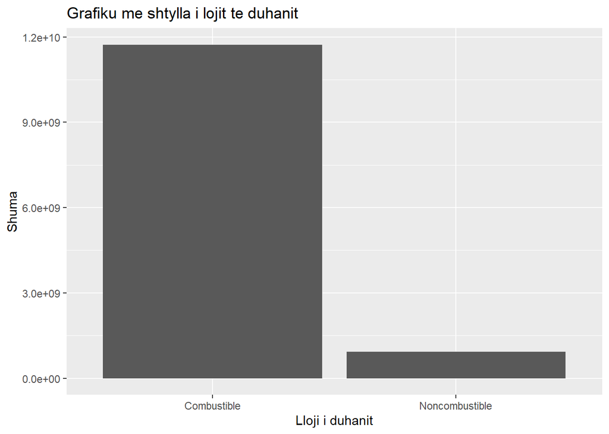

```r
p<-ggplot(data=data, aes(x=group, y=value)) + geom_bar(stat="identity")+labs(x = "Lloji i duhanit",y = "Shuma",title = "Grafiku me shtylla i lojit te duhanit")
p
```

Nga dy grafiket duket qarte se lloji i duhanit qe prodhohet dhe rrjedhimisht konsumohet me shume eshte ai i djegshem.

Shohim sesi esht raporti i tyre nder vite.

```r
#Gjejme totalin e secilit lloj ne cdo vit
library(dplyr)
df <- df%>%group_by(Year,Topic)%>%mutate(cum_topic = cumsum(Totali_Pounds))
```

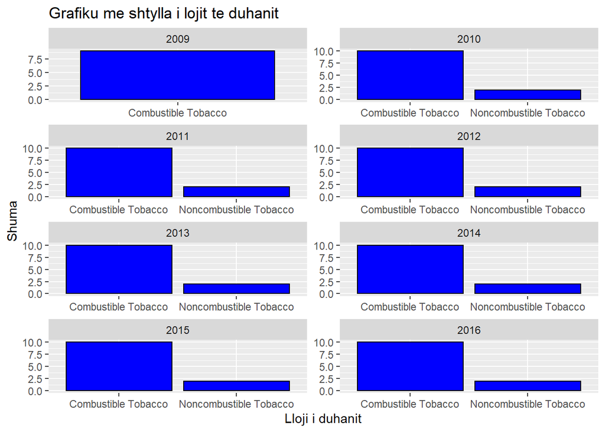

```r
ggplot(df, aes(x = Topic)) +geom_bar(fill = "blue",color="black") +labs(x = "Lloji i duhanit",y = "Shuma",title = "Grafiku me shtylla i lojit te duhanit")+facet_wrap(~Year, scale="free", ncol = 2, nrow = 4)
```

Edhe nga keto grafike per 8 vite dallohet nje dominim i tregut nga duhani i djegshem (per vitin 2009 mungojne te dhenat per duhanin e padjegshem ne databaze).

Ndryshimi nder vite i llojeve te duhanit.

```r
#ndertojme nje dataframe me perqindjen qe ze duhani i djegshem ne sasine totale te duhanit cdo vit
years = c(2009,2010,2011,2012,2013,2014,2015,2016)
b1=sum(df[which(df$Topic=='Combustible Tobacco' & df$Year == 2009), 15])/sum(df[which(df$Year==2009),15])*100
b2=sum(df[which(df$Topic=='Combustible Tobacco' & df$Year == 2010), 15])/sum(df[which(df$Year==2010),15])*100
b3=sum(df[which(df$Topic=='Combustible Tobacco' & df$Year == 2011), 15])/sum(df[which(df$Year==2011),15])*100
b4=sum(df[which(df$Topic=='Combustible Tobacco' & df$Year == 2012), 15])/sum(df[which(df$Year==2012),15])*100
b5=sum(df[which(df$Topic=='Combustible Tobacco' & df$Year == 2013), 15])/sum(df[which(df$Year==2013),15])*100
b6=sum(df[which(df$Topic=='Combustible Tobacco' & df$Year == 2014), 15])/sum(df[which(df$Year==2014),15])*100
b7=sum(df[which(df$Topic=='Combustible Tobacco' & df$Year == 2015), 15])/sum(df[which(df$Year==2015),15])*100
b8=sum(df[which(df$Topic=='Combustible Tobacco' & df$Year == 2016), 15])/sum(df[which(df$Year==2016),15])*100
perqindja = c(b1,b2,b3,b4,b5,b6,b7,b8)

combustible = data.frame(years, perqindja)
combustible
```

```
##   years perqindja
## 1  2009 100.00000
## 2  2010  92.14097
## 3  2011  92.22744
## 4  2012  91.97775
## 5  2013  91.58563
## 6  2014  91.25968
## 7  2015  91.25129
## 8  2016  90.86800
```

```r
library(hrbrthemes)
```

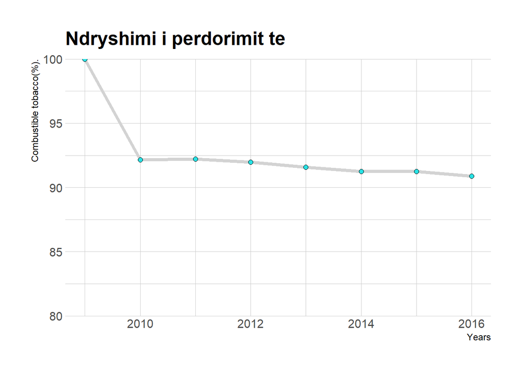

```r
ggplot(data=combustible, aes(x=years, y=perqindja, group=1)) +geom_line(size = 1.5,

color = "lightgray")+geom_point(shape=21,

color = "black", fill="69b3a2", size=2)+theme_ipsum()+labs(y ="Combustible tobacco(%).",
x = "Years",
title = "Ndryshimi i perdorimit te")+
scale_y_continuous(expand=c(0,0),limits =c(80,100))
```

Grafiku tregon nje vije pothuajse lineare (pervec vitit te pare) me nje renie te lehte ne vitet e fundit, gjithsesi duhani i djegshem duket se do te vazhdoje te perbeje mbi 90% te prodhimit edhe per shume vite te ardhshme.

Bejme te njejten gje per duhanin e padjegshem.

```r
years = c(2009,2010,2011,2012,2013,2014,2015,2016)
nc1=0
nc2=sum(df[which(df$Topic=='Noncombustible Tobacco' & df$Year == 2010), 15])/sum(df[which(df$Year==2010),15])*100
nc3=sum(df[which(df$Topic=='Noncombustible Tobacco' & df$Year == 2011), 15])/sum(df[which(df$Year==2011),15])*100
nc4=sum(df[which(df$Topic=='Noncombustible Tobacco' & df$Year == 2012), 15])/sum(df[which(df$Year==2012),15])*100
nc5=sum(df[which(df$Topic=='Noncombustible Tobacco' & df$Year == 2013), 15])/sum(df[which(df$Year==2013),15])*100
nc6=sum(df[which(df$Topic=='Noncombustible Tobacco' & df$Year == 2014), 15])/sum(df[which(df$Year==2014),15])*100
nc7=sum(df[which(df$Topic=='Noncombustible Tobacco' & df$Year == 2015), 15])/sum(df[which(df$Year==2015),15])*100
nc8=sum(df[which(df$Topic=='Noncombustible Tobacco' & df$Year == 2016), 15])/sum(df[which(df$Year==2016),15])*100
perqindja = c(nc1,nc2,nc3,nc4,nc5,nc6,nc7,nc8)

noncombustible = data.frame(years, perqindja)
noncombustible
```

```
##   years perqindja
## 1  2009  0.000000
## 2  2010  7.859028
## 3  2011  7.772559
## 4  2012  8.022253
## 5  2013  8.414367
## 6  2014  8.740318
## 7  2015  8.748710
## 8  2016  9.132005
```

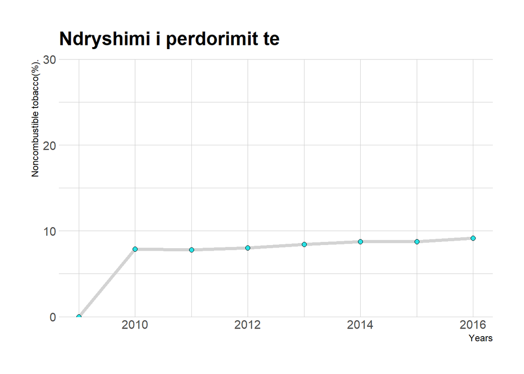

```r
ggplot(data=noncombustible, aes(x=years, y=perqindja, group=1)) +geom_line(size = 1.5,

color = "lightgray")+geom_point(shape=21,

color = "black", fill="69b3a2", size=2)+theme_ipsum()+labs(y ="Noncombustible tobacco(%).",
x = "Years",
title = "Ndryshimi i perdorimit te")+
scale_y_continuous(expand=c(0,0),limits =c(0,30))
```

Shohim te njejten gje si ne rastin e pare, vetem se ne kete rast jemi ne “dyshemene” e grafikut, duhani i padjegshem nuk eshte ende popullor megjithese vitet e fundit duket nje rritje e lehte e prodhimit te tij.

### Analiza e te dhenave 2

Ne kete tab do te analizojme prodhimit e nenllojeve te duhanit.

E nisim me cigaret normale:

```r
#gjejme shumen e cigareve totale te prodhuara cdo vit dhe i vendosim ne nje dataframe
years = c(2009,2010,2011,2012,2013,2014,2015,2016)
cg1= sum(df[which(df$Measure=='Cigarettes' & df$Year == 2009), 11])
cg2= sum(df[which(df$Measure=='Cigarettes' & df$Year == 2010), 11])
cg3 = sum(df[which(df$Measure=='Cigarettes' & df$Year == 2011), 11])
cg4 = sum(df[which(df$Measure=='Cigarettes' & df$Year == 2012), 11])
cg5 = sum(df[which(df$Measure=='Cigarettes' & df$Year == 2013), 11])
cg6 = sum(df[which(df$Measure=='Cigarettes' & df$Year == 2014), 11])
cg7 = sum(df[which(df$Measure=='Cigarettes' & df$Year == 2015), 11])
cg8 = sum(df[which(df$Measure=='Cigarettes' & df$Year == 2016), 11])
cigrt = c(cg1,cg2,cg3,cg4,cg5,cg6,cg7,cg8)
cigarettes = data.frame(years,cigrt)
cigarettes
```

```
##   years        cigrt
## 1  2009 317736074658
## 2  2010 300450783443
## 3  2011 292769084912
## 4  2012 287187201182
## 5  2013 273785498153
## 6  2014 262681273103
## 7  2015 268260776991
## 8  2016 257453734796
```

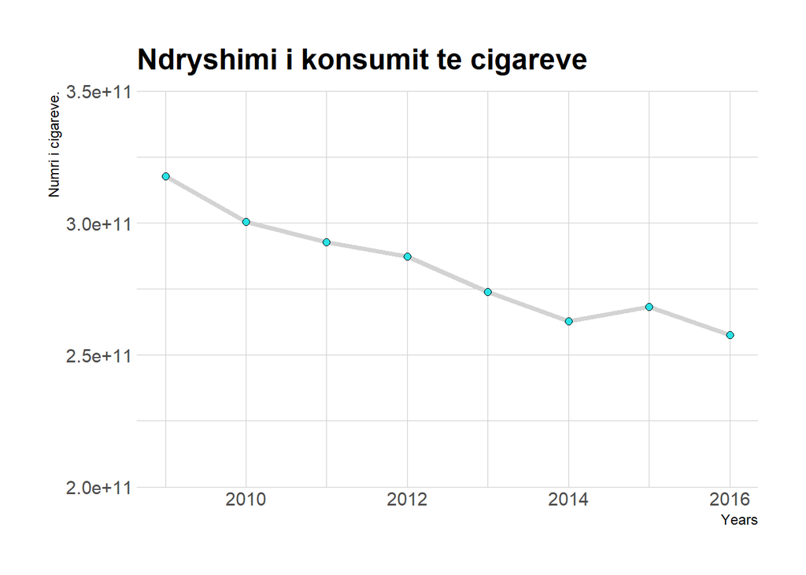

```r
ggplot(data=cigarettes, aes(x=years, y=cigrt, group=1)) +geom_line(size = 1.5,

color = "lightgray")+geom_point(shape=21,

color = "black", fill="69b3a2", size=2)+theme_ipsum()+labs(y ="Numri i cigareve.",
x = "Years",
title = "Ndryshimi i konsumit te cigareve")+
scale_y_continuous(expand=c(0,0),limits =c(200000000000,350000000000))
```

```r
years = c(2010,2011,2012,2013,2014,2015,2016)
sl2= sum(df[which(df$Measure=='Smokeless Tobacco' & df$Year == 2010), 11])
sl3 = sum(df[which(df$Measure=='Smokeless Tobacco' & df$Year == 2011), 11])
sl4 = sum(df[which(df$Measure=='Smokeless Tobacco' & df$Year == 2012), 11])
sl5 = sum(df[which(df$Measure=='Smokeless Tobacco' & df$Year == 2013), 11])
sl6 = sum(df[which(df$Measure=='Smokeless Tobacco' & df$Year == 2014), 11])
sl7 = sum(df[which(df$Measure=='Smokeless Tobacco' & df$Year == 2015), 11])
sl8 = sum(df[which(df$Measure=='Smokeless Tobacco' & df$Year == 2016), 11])
smless = c(sl2,sl3,sl4,sl5,sl6,sl7,sl8)
smokeless = data.frame(years,smless)
smokeless
```

```
##   years    smless
## 1  2010 127527161
## 2  2011 128362507
## 3  2012 132351339
## 4  2013 135440326
## 5  2014 136333155
## 6  2015 137782941
## 7  2016 139089970
```

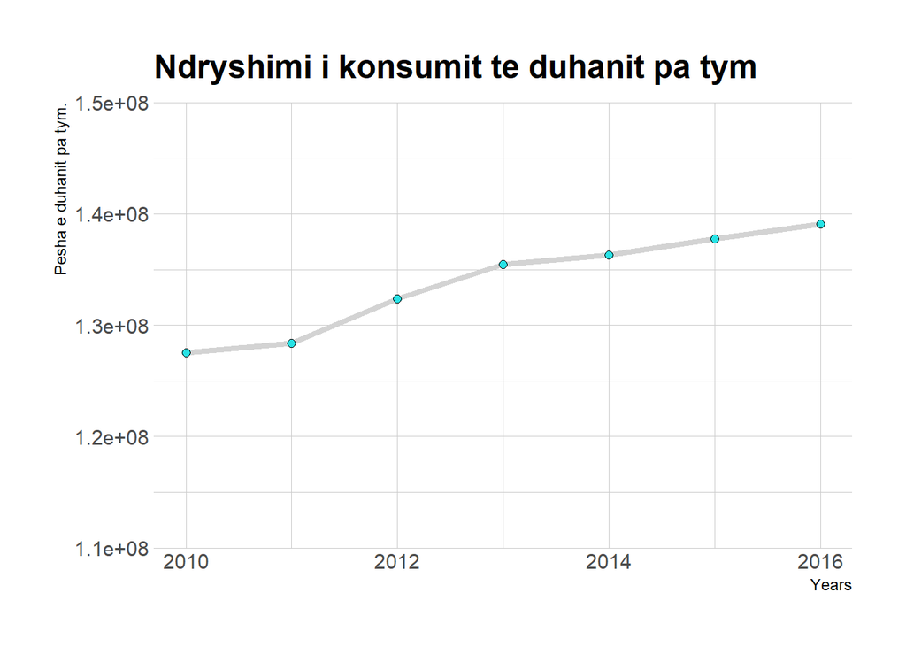

```r
ggplot(data=smokeless, aes(x=years, y=smless, group=1)) +geom_line(size = 1.5,

color = "lightgray")+geom_point(shape=21,

color = "black", fill="69b3a2", size=2)+theme_ipsum()+labs(y ="Pesha e duhanit pa tym.",
x = "Years",
title = "Ndryshimi i konsumit te duhanit pa tym")+
scale_y_continuous(expand=c(0,0),limits =c(110000000,150000000))
```

Nga grafiku shohim nje rritje ne numrin e duhanit pa tym te prodhuar vitet e fundit, kjo esht ne perputhje me rritjen qe pame ne grafikun e duhanit te padjegshem.

```r
years = c(2009,2010,2011,2012,2013,2014,2015)
cr1 = sum(df[which(df$Measure=='Cigars' & df$Year == 2009), 11])
cr2= sum(df[which(df$Measure=='Cigars' & df$Year == 2010), 11])
cr3 = sum(df[which(df$Measure=='Cigars' & df$Year == 2011), 11])
cr4 = sum(df[which(df$Measure=='Cigars' & df$Year == 2012), 11])
cr5 = sum(df[which(df$Measure=='Cigars' & df$Year == 2013), 11])
cr6 = sum(df[which(df$Measure=='Cigars' & df$Year == 2014), 11])
cr7 = sum(df[which(df$Measure=='Cigars' & df$Year == 2015), 11])
cgrs = c(cr1,cr2,cr3,cr4,cr5,cr6,cr7)
cigars = data.frame(years,cgrs)
cigars
```

```
##   years        cgrs
## 1  2009 14469142198
## 2  2010 26538813120
## 3  2011 27454560916
## 4  2012 27573614478
## 5  2013 26317742576
## 6  2014 27389105104
## 7  2015 25586922572
```

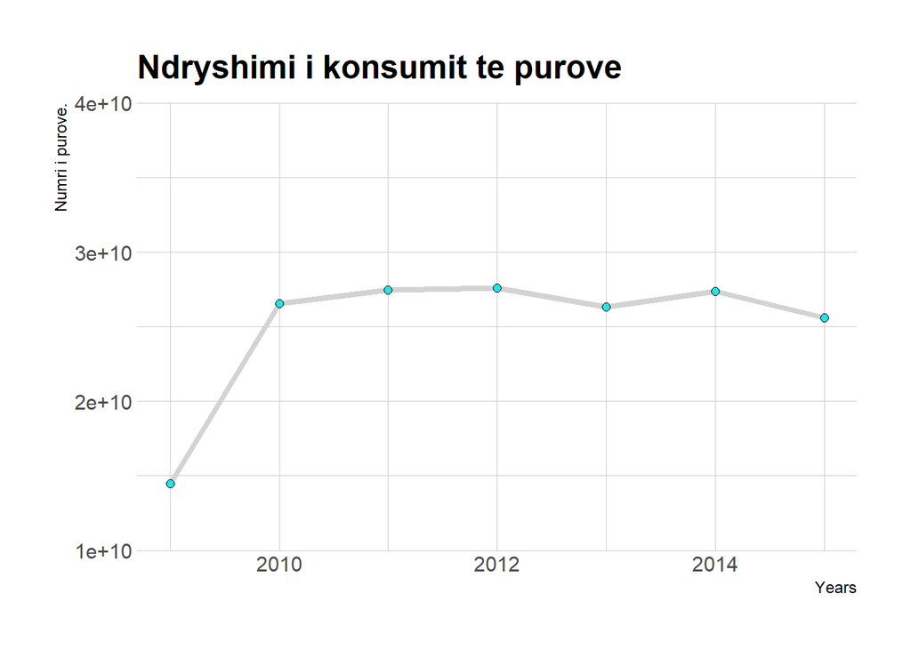

```r
ggplot(data=cigars, aes(x=years, y=cgrs, group=1)) +geom_line(size = 1.5,

color = "lightgray")+geom_point(shape=21,

color = "black", fill="69b3a2", size=2)+theme_ipsum()+labs(y ="Numri i purove.",
x = "Years",
title = "Ndryshimi i konsumit te purove")+
scale_y_continuous(expand=c(0,0),limits =c(10000000000,40000000000))
```

Nga ky grafik mund te themi se prodhimi dhe konsumi i purove ka qene konstant ne vitet e fundit, duke treguar se ka nje grup konsumatoresh mjaft besnike.

```r
years = c(2009,2010,2011,2012,2013,2014,2015,2016)
lt1 = sum(df[which(df$Measure=='Loose Tobacco' & df$Year == 2009), 11])
lt2= sum(df[which(df$Measure=='Loose Tobacco' & df$Year == 2010), 11])
lt3 = sum(df[which(df$Measure=='Loose Tobacco' & df$Year == 2011), 11])
lt4 = sum(df[which(df$Measure=='Loose Tobacco' & df$Year == 2012), 11])
lt5 = sum(df[which(df$Measure=='Loose Tobacco' & df$Year == 2013), 11])
lt6 = sum(df[which(df$Measure=='Loose Tobacco' & df$Year == 2014), 11])
lt7 = sum(df[which(df$Measure=='Loose Tobacco' & df$Year == 2015), 11])
lt8 = sum(df[which(df$Measure=='Loose Tobacco' & df$Year == 2016), 11])
loose = c(lt1,lt2,lt3,lt4,lt5,lt6,lt7,lt8)
loose_tbc = data.frame(years,loose)
loose_tbc
```

```
##   years       loose
## 1  2009 24572637836
## 2  2010 31101086635
## 3  2011 40243428850
## 4  2012 42931871912
## 5  2013 45485533445
## 6  2014 43728771023
## 7  2015 43482236558
## 8  2016 42195084314
```

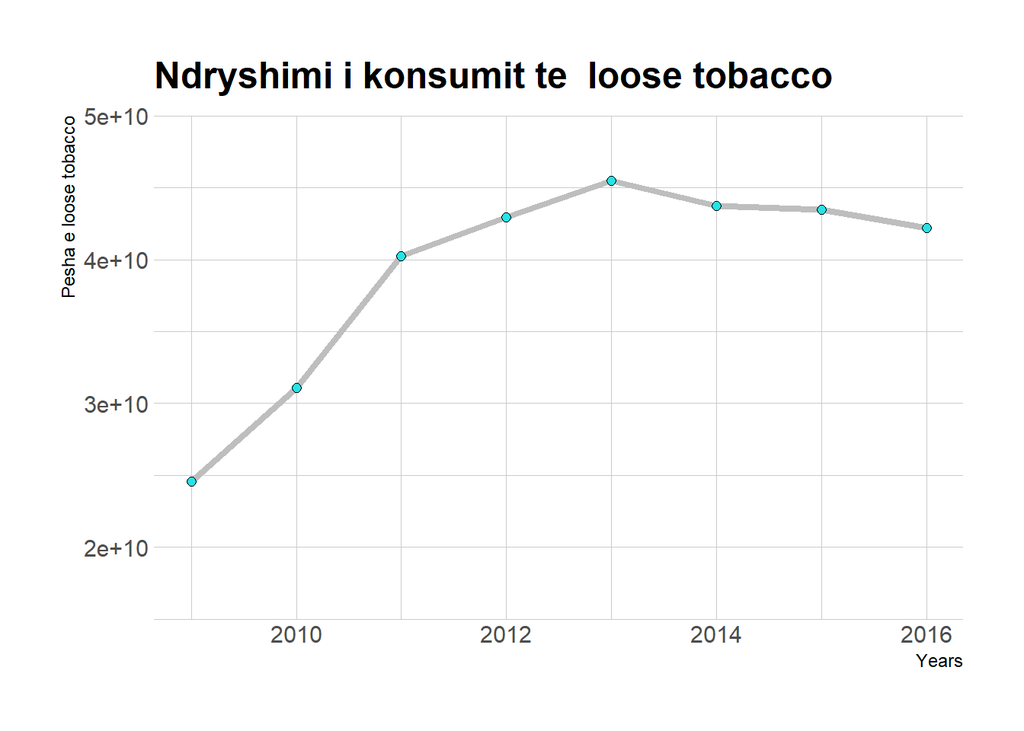

```r
ggplot(data=loose_tbc, aes(x=years, y=loose, group=1)) +geom_line(size = 1.5,

color = "gray")+geom_point(shape=21,

color = "black", fill="69b3a2", size=2)+theme_ipsum() +labs(y ="Pesha e loose tobacco",
x = "Years",
title = "Ndryshimi i konsumit te  loose tobacco")+
scale_y_continuous(expand=c(0,0),limits =c(15000000000,50000000000))
```

Ndertojme nje grafik me shtylla per te pare peshen qe ze secili nenlloj ne treg.

```r
#krijojme nje vektor me emrat e nenllojeve
nenllojet = c('Loose Tobacco','Cigarettes','Cigars','Smokeless Tobacco')

#gjejme shumen e secilit nenlloj ne total gjate gjithe viteve
lt = sum(df[which(df$Measure=='Loose Tobacco'), 15])
cr = sum(df[which(df$Measure=='Cigarettes'), 15])
cg = sum(df[which(df$Measure=='Cigars'), 15])
st = sum(df[which(df$Measure=='Smokeless Tobacco'), 15])
dg = c(lt,cr,cg,st)
dtf = data.frame(nenllojet,dg)
dtf
```

```
##           nenllojet         dg
## 1     Loose Tobacco 1888412461
## 2        Cigarettes 9041297709
## 3            Cigars  801545885
## 4 Smokeless Tobacco  936887399
```

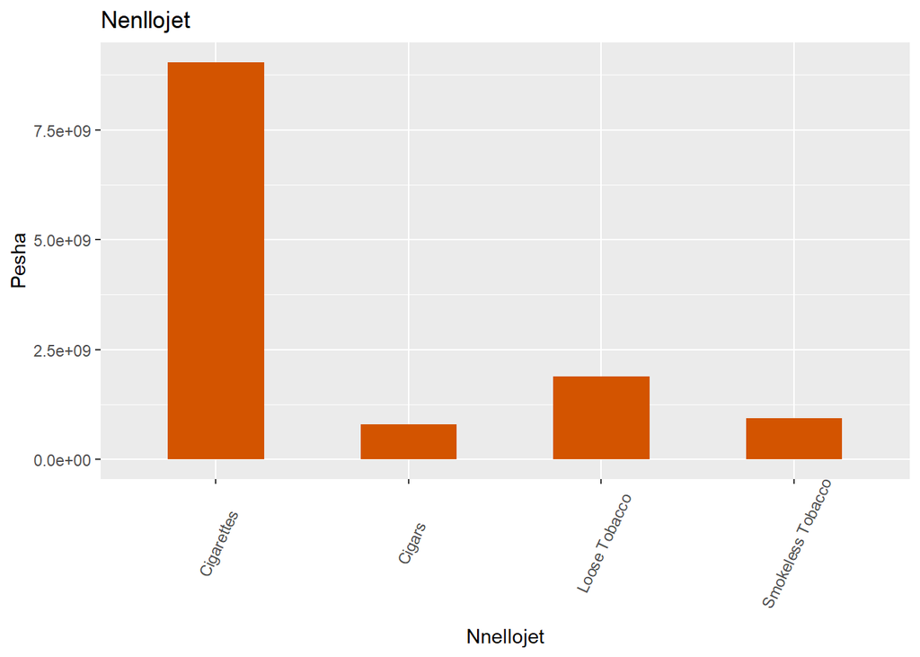

```r
ggplot(dtf, aes(x=nenllojet, y=dg)) + geom_bar(stat="identity", width=.5, fill="#D35400") + labs(title="Nenllojet") + xlab("Nnellojet") + ylab("Pesha") + theme(axis.text.x = element_text(angle=65, vjust=0.6))
```

Dallohet qarte dominimi i cigareve normale ne treg ne krahasim me te gjitha llojet e tjera se bashku. Kjo ishte e pritshme pasi cigaret normale konsumohen rendomte ne publik nga te gjitha moshat dhe jane bere pjese e pandashme e atyre qe i konsumojne. Ndryshe nga llojet e tjera te cilat jane me te rezervuara per tu konsumuar, per shkak te sasise se duhanit por edhe cmimit.

### Perfundimet

Perfundime Ne perfundim te ketij projekti u arrit te analizoheshin te dhenat e databazes se dhene, duke dale ne disa konkluzione te rendesishme mbi prodhimin dhe konsumin e duhanit ne US. Pame se lloji i duhanit qe dominon tregun eshte ai i djegshmi, pasi ka me tradite dhe eshte me i reklamuar nder vite prandaj njerezit e njohin me mire dhe priren drejt konsumit te tij. Megjithate nuk do te ishte e habitshme nese mbas disa vitesh raportet do te ndryshojne duke pare rritjen e lehte ne vitet e fundit te duhanit te padjegshem. Nga nenllojet ishte e pritshme sasia e larte e cigareve normale qe konsumohen krahasuar me te gjitha nenllojet e tjera.

Do te jete interesante vazhdimi i ketij studimi ne vitet e ardhshme per te pare nese do te kete nje ndryshim te raporteve te sinjalizuara nga ky studim. Do te ishte e rendesishme perfshirja e faktoreve te tjere ne studim te cilet mungonin ne kete databaze, si per shembull te dhenat e plota per secilin vit, apo edhe te dhena shtese si cmimi, fitimi ose lidhja me pasojat qe shkakton konsumi i duhanit.

### Referencat

Referenca:

https://www.cdc.gov/mmwr/preview/mmwrhtml/mm6130a1.htm#tab2 https://r-graph-gallery.com/piechart-ggplot2.html https://r-graph-gallery.com/connected_scatterplot_ggplot2.html http://www.sthda.com/english/wiki/ggplot2-barplots-quick-start-guide-r-software-and-data-visualization https://www.ncbi.nlm.nih.gov/pmc/articles/PMC4127802/ https://tobaccocontrol.bmj.com/content/7/2/168 https://statisticsglobe.com/cumsum-r-function-explained/ https://stackoverflow.com/questions/22127342/how-to-remove-rows-in-a-dataframe-that-contain-certain-words-in-r https://stackoverflow.com/questions/72227607/how-to-adjust-the-ratio-of-my-x-axis-in-my-line-graph-in-r https://dplyr.tidyverse.org/reference/group_by.html https://www.rdocumentation.org/packages/ggplot2/versions/3.3.6/topics/facet_wrap Hyrje ne statistiken e zbatuar 3 - Llukan Puka